# ADS503 - Module 1 Lab

Satya Allumallu

1/20/2022

### R Data Types

We will review vectors, matrices, data frames and list data types, these are the most commonly used data types in R. For more details on R data types see https://www.statmethods.net/input/datatypes.html. We will also see how to find more information about these R objects.

```r
xn <- c(1, 2, 3) # numeric vector
yn = c(1, 2, 3)

str(xn) # structure of the R object
```

```
##  num [1:3] 1 2 3
```

```r
class(xn) # class of the object
```

```
## [1] "numeric"
```

```r
xc <- c('a', 'b', 'c') # character vector

str(xc)
```

```
##  chr [1:3] "a" "b" "c"
```

```r
class(xc)
```

```
## [1] "character"
```

```r
xm <- matrix(1:20, nrow = 5, ncol = 4) # matrix
xm
```

```
##      [,1] [,2] [,3] [,4]
## [1,]    1    6   11   16
## [2,]    2    7   12   17
## [3,]    3    8   13   18
## [4,]    4    9   14   19
## [5,]    5   10   15   20
```

```r
?matrix

xm1 <- matrix(1:20, nrow = 5, ncol = 4, byrow = TRUE) # matrix
xm1
```

```
##      [,1] [,2] [,3] [,4]
## [1,]    1    2    3    4
## [2,]    5    6    7    8
## [3,]    9   10   11   12
## [4,]   13   14   15   16
## [5,]   17   18   19   20
```

```r
str(xm1)
```

```
##  int [1:5, 1:4] 1 5 9 13 17 2 6 10 14 18 ...
```

```r
class(xm1)
```

```
## [1] "matrix"
```

```r
xl <- list(a = 1:10, beta = exp(-3:3), logic = c(TRUE, FALSE, FALSE, TRUE)) # list
xl$a
```

```
##  [1]  1  2  3  4  5  6  7  8  9 10
```

```r
xl[[2]]
```

```
## [1]  0.04978707  0.13533528  0.36787944  1.00000000  2.71828183  7.38905610
## [7] 20.08553692
```

```r
str(xl)
```

```
## List of 3
##  $ a    : int [1:10] 1 2 3 4 5 6 7 8 9 10
##  $ beta : num [1:7] 0.0498 0.1353 0.3679 1 2.7183 ...
##  $ logic: logi [1:4] TRUE FALSE FALSE TRUE
```

```r
class(xl)
```

```
## [1] "list"
```

```r
xd <- data.frame(x = 1:10, y = letters[1:10],
                 z = rep(c(TRUE, FALSE), 5)) # data frame
str(xd)
```

```
## 'data.frame':    10 obs. of  3 variables:
##  $ x: int  1 2 3 4 5 6 7 8 9 10
##  $ y: Factor w/ 10 levels "a","b","c","d",..: 1 2 3 4 5 6 7 8 9 10
##  $ z: logi  TRUE FALSE TRUE FALSE TRUE FALSE ...
```

```r
class(xd)
```

```
## [1] "data.frame"
```

```r
head(xd)
```

```
##   x y     z
## 1 1 a  TRUE
## 2 2 b FALSE
## 3 3 c  TRUE
## 4 4 d FALSE
## 5 5 e  TRUE
## 6 6 f FALSE
```

```r
xd1 <- data.frame(x = 1:10, y = letters[1:10],
                 z = rep(c(TRUE, FALSE), 5), stringsAsFactors = FALSE) # data frame
str(xd1)
```

```
## 'data.frame':    10 obs. of  3 variables:
##  $ x: int  1 2 3 4 5 6 7 8 9 10
##  $ y: chr  "a" "b" "c" "d" ...
##  $ z: logi  TRUE FALSE TRUE FALSE TRUE FALSE ...
```

```r
head(xd1)
```

```
##   x y     z
## 1 1 a  TRUE
## 2 2 b FALSE
## 3 3 c  TRUE
## 4 4 d FALSE
## 5 5 e  TRUE
## 6 6 f FALSE
```

```r
names(xd1) # names of columns in data frame
```

```
## [1] "x" "y" "z"
```

```r
dim(xd1) # dimension of data frame
```

```
## [1] 10  3
```

```r
nrow(xd1) # number of rows of data frame
```

```
## [1] 10
```

```r
ncol(xd1) # number of columns of data frame
```

```
## [1] 3
```

```r
# Accessing data frames

xd1[1, ] # first row
```

```
##   x y    z
## 1 1 a TRUE
```

```r
xd1[, 1] # first column
```

```
##  [1]  1  2  3  4  5  6  7  8  9 10
```

```r
xd1[2, 3] # second row and third column
```

```
## [1] FALSE
```

```r
xd1[, c("y", "z")] # data frame columns y and z
```

```
##    y     z
## 1  a  TRUE
## 2  b FALSE
## 3  c  TRUE
## 4  d FALSE
## 5  e  TRUE
## 6  f FALSE
## 7  g  TRUE
## 8  h FALSE
## 9  i  TRUE
## 10 j FALSE
```

```r
xd1[xd1$x > 5, ] # subset data frame
```

```
##     x y     z
## 6   6 f FALSE
## 7   7 g  TRUE
## 8   8 h FALSE
## 9   9 i  TRUE
## 10 10 j FALSE
```

```r
xds <- subset(xd1, x > 5) # subset data frame
subset(xd1, x > 5 & z == TRUE) # subset data frame
```

```
##   x y    z
## 7 7 g TRUE
## 9 9 i TRUE
```

```r
xds1 <- subset(xd1, x > 5, select = c(x, y)) # subset and select data frame
xds2 <- subset(xd1, x > 5, select = -z) # subset and select data frame
```

### Reading and writing files in R

```r
getwd()
```

```
## [1] "/Users/sallumallu/Desktop/Online_Courses/USD_Course/MADS503/Module1"
```

```r
setwd('/Users/sallumallu/Desktop/Online_Courses/USD_Course/MADS503/Module1')
read_df1 <- read.csv('/Users/sallumallu/Desktop/Online_Courses/USD_Course/MADS503/Module1/hcvdat0.csv')
str(read_df1)
```

```
## 'data.frame':    615 obs. of  14 variables:
##  $ X       : int  1 2 3 4 5 6 7 8 9 10 ...
##  $ Category: Factor w/ 5 levels "0=Blood Donor",..: 1 1 1 1 1 1 1 1 1 1 ...
##  $ Age     : int  32 32 32 32 32 32 32 32 32 32 ...
##  $ Sex     : Factor w/ 2 levels "f","m": 2 2 2 2 2 2 2 2 2 2 ...
##  $ ALB     : num  38.5 38.5 46.9 43.2 39.2 41.6 46.3 42.2 50.9 42.4 ...
##  $ ALP     : num  52.5 70.3 74.7 52 74.1 43.3 41.3 41.9 65.5 86.3 ...
##  $ ALT     : num  7.7 18 36.2 30.6 32.6 18.5 17.5 35.8 23.2 20.3 ...
##  $ AST     : num  22.1 24.7 52.6 22.6 24.8 19.7 17.8 31.1 21.2 20 ...
##  $ BIL     : num  7.5 3.9 6.1 18.9 9.6 12.3 8.5 16.1 6.9 35.2 ...
##  $ CHE     : num  6.93 11.17 8.84 7.33 9.15 ...
##  $ CHOL    : num  3.23 4.8 5.2 4.74 4.32 6.05 4.79 4.6 4.1 4.45 ...
##  $ CREA    : num  106 74 86 80 76 111 70 109 83 81 ...
##  $ GGT     : num  12.1 15.6 33.2 33.8 29.9 91 16.9 21.5 13.7 15.9 ...
##  $ PROT    : num  69 76.5 79.3 75.7 68.7 74 74.5 67.1 71.3 69.9 ...
```

```r
read_df2 <- read.csv('/Users/sallumallu/Desktop/Online_Courses/USD_Course/MADS503/Module1/hcvdat0.csv',
                    stringsAsFactors = FALSE)
str(read_df2)
```

```
## 'data.frame':    615 obs. of  14 variables:
##  $ X       : int  1 2 3 4 5 6 7 8 9 10 ...
##  $ Category: chr  "0=Blood Donor" "0=Blood Donor" "0=Blood Donor" "0=Blood Donor" ...
##  $ Age     : int  32 32 32 32 32 32 32 32 32 32 ...
##  $ Sex     : chr  "m" "m" "m" "m" ...
##  $ ALB     : num  38.5 38.5 46.9 43.2 39.2 41.6 46.3 42.2 50.9 42.4 ...
##  $ ALP     : num  52.5 70.3 74.7 52 74.1 43.3 41.3 41.9 65.5 86.3 ...
##  $ ALT     : num  7.7 18 36.2 30.6 32.6 18.5 17.5 35.8 23.2 20.3 ...
##  $ AST     : num  22.1 24.7 52.6 22.6 24.8 19.7 17.8 31.1 21.2 20 ...
##  $ BIL     : num  7.5 3.9 6.1 18.9 9.6 12.3 8.5 16.1 6.9 35.2 ...
##  $ CHE     : num  6.93 11.17 8.84 7.33 9.15 ...
##  $ CHOL    : num  3.23 4.8 5.2 4.74 4.32 6.05 4.79 4.6 4.1 4.45 ...
##  $ CREA    : num  106 74 86 80 76 111 70 109 83 81 ...
##  $ GGT     : num  12.1 15.6 33.2 33.8 29.9 91 16.9 21.5 13.7 15.9 ...
##  $ PROT    : num  69 76.5 79.3 75.7 68.7 74 74.5 67.1 71.3 69.9 ...
```

```r
write.csv(xds2, file = 'xds2.csv')
```

### Apply functions in R.

We will review some of the apply functions in R. These are very useful and handy functions in base R that help you avoid using loops and write clean code. For more details on apply functions see https://ademos.people.uic.edu/Chapter4.html.

```r
data(cars)
head(cars)
```

```
##   speed dist
## 1     4    2
## 2     4   10
## 3     7    4
## 4     7   22
## 5     8   16
## 6     9   10
```

```r
dim(cars)
```

```
## [1] 50  2
```

```r
apply(cars, 1, mean) # row mean
```

```
##  [1]  3.0  7.0  5.5 14.5 12.0  9.5 14.0 18.0 22.0 14.0 19.5 13.0 16.0 18.0 20.0
## [16] 19.5 23.5 23.5 29.5 20.0 25.0 37.0 47.0 17.5 20.5 34.5 24.0 28.0 24.5 28.5
## [31] 33.5 30.0 37.0 47.0 51.0 27.5 32.5 43.5 26.0 34.0 36.0 38.0 42.0 44.0 38.5
## [46] 47.0 58.0 58.5 72.0 55.0
```

```r
apply(cars, 2, mean) # column mean
```

```
## speed  dist
## 15.40 42.98
```

```r
data(airquality)
head(airquality)
```

```
##   Ozone Solar.R Wind Temp Month Day
## 1    41     190  7.4   67     5   1
## 2    36     118  8.0   72     5   2
## 3    12     149 12.6   74     5   3
## 4    18     313 11.5   62     5   4
## 5    NA      NA 14.3   56     5   5
## 6    28      NA 14.9   66     5   6
```

```r
aq_class <- lapply(airquality, class) # get class of each column in the data frame
aq_class
```

```
## $Ozone
## [1] "integer"
##
## $Solar.R
## [1] "integer"
##
## $Wind
## [1] "numeric"
##
## $Temp
## [1] "integer"
##
## $Month
## [1] "integer"
##
## $Day
## [1] "integer"
```

```r
aq_mean <- lapply(airquality, mean) # get mean of each column in the data frame
aq_mean
```

```
## $Ozone
## [1] NA
##
## $Solar.R
## [1] NA
##
## $Wind
## [1] 9.957516
##
## $Temp
## [1] 77.88235
##
## $Month
## [1] 6.993464
##
## $Day
## [1] 15.80392
```

```r
aq_mean_cleaned <- lapply(airquality, mean, na.rm = TRUE) # get mean of each column in the data frame
aq_mean_cleaned
```

```
## $Ozone
## [1] 42.12931
##
## $Solar.R
## [1] 185.9315
##
## $Wind
## [1] 9.957516
##
## $Temp
## [1] 77.88235
##
## $Month
## [1] 6.993464
##
## $Day
## [1] 15.80392
```

```r
airquality_s <- airquality[, lapply(airquality, class) == 'integer'] # subset
# data frame using lapply function

sapply(airquality, function(x) sum(is.na(x))) # using sapply to find NA's
```

```
##   Ozone Solar.R    Wind    Temp   Month     Day
##      37       7       0       0       0       0
```

```r
aq_mean_cleaned_vector <- sapply(airquality, mean, na.rm = TRUE)
aq_mean_cleaned_vector
```

```
##      Ozone    Solar.R       Wind       Temp      Month        Day
##  42.129310 185.931507   9.957516  77.882353   6.993464  15.803922
```

```r
names(aq_mean_cleaned_vector)
```

```
## [1] "Ozone"   "Solar.R" "Wind"    "Temp"    "Month"   "Day"
```

### Some useful functions in R for module 1

pairs, cor, boxplot and skewness

```r
data(iris)
str(iris)
```

```
## 'data.frame':    150 obs. of  5 variables:
##  $ Sepal.Length: num  5.1 4.9 4.7 4.6 5 5.4 4.6 5 4.4 4.9 ...
##  $ Sepal.Width : num  3.5 3 3.2 3.1 3.6 3.9 3.4 3.4 2.9 3.1 ...
##  $ Petal.Length: num  1.4 1.4 1.3 1.5 1.4 1.7 1.4 1.5 1.4 1.5 ...
##  $ Petal.Width : num  0.2 0.2 0.2 0.2 0.2 0.4 0.3 0.2 0.2 0.1 ...
##  $ Species     : Factor w/ 3 levels "setosa","versicolor",..: 1 1 1 1 1 1 1 1 1 1 ...
```

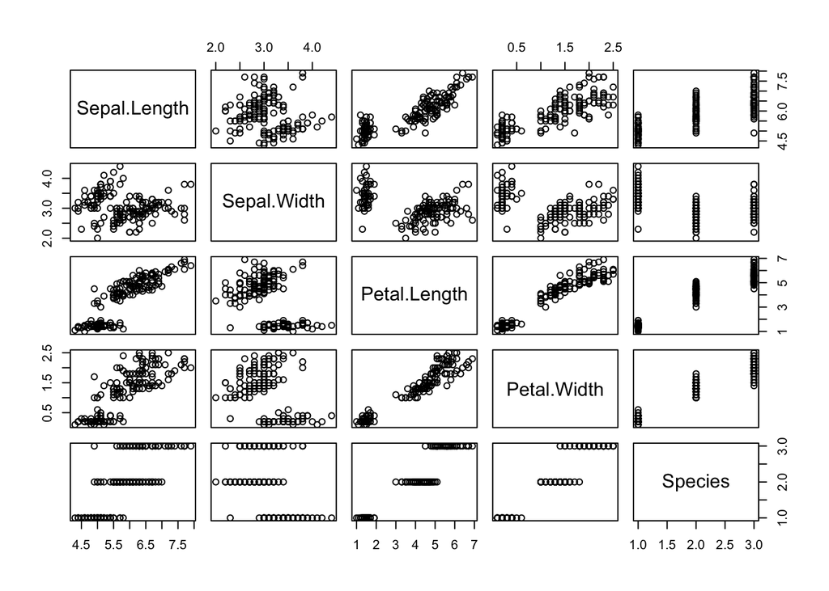

```r
pairs(iris) # pairwise scatter plots
```

```r
#cor(iris) # correlation between predictors

cor(iris[,-5])
```

```
##              Sepal.Length Sepal.Width Petal.Length Petal.Width
## Sepal.Length    1.0000000  -0.1175698    0.8717538   0.8179411
## Sepal.Width    -0.1175698   1.0000000   -0.4284401  -0.3661259
## Petal.Length    0.8717538  -0.4284401    1.0000000   0.9628654
## Petal.Width     0.8179411  -0.3661259    0.9628654   1.0000000
```

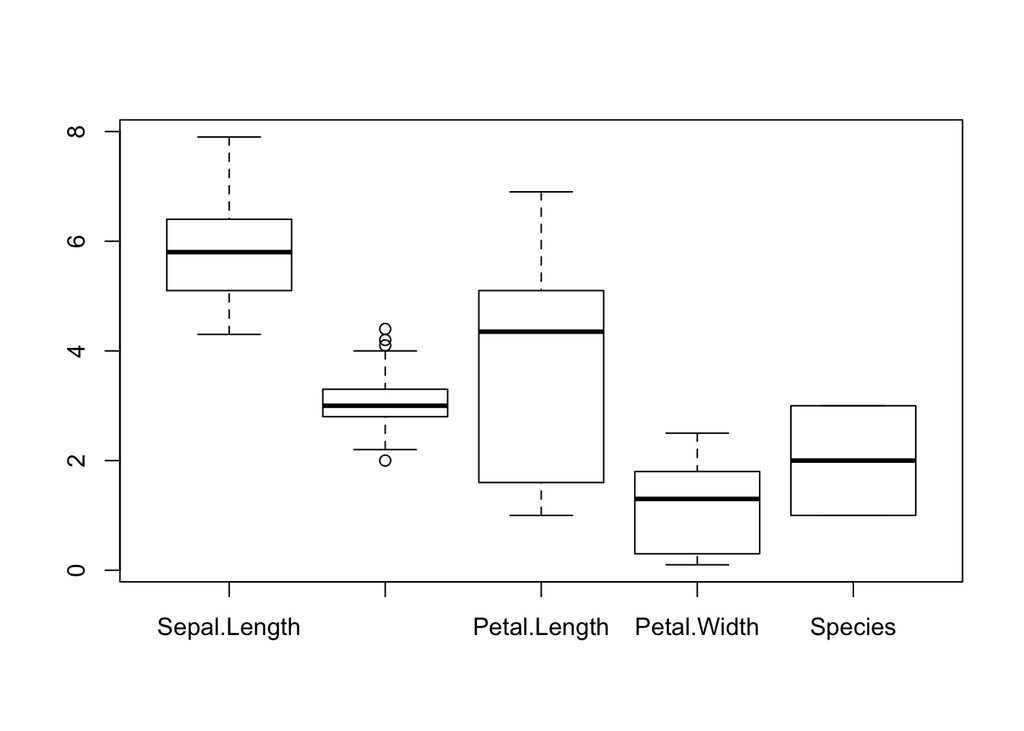

```r
# some boxplots
boxplot(iris)
```

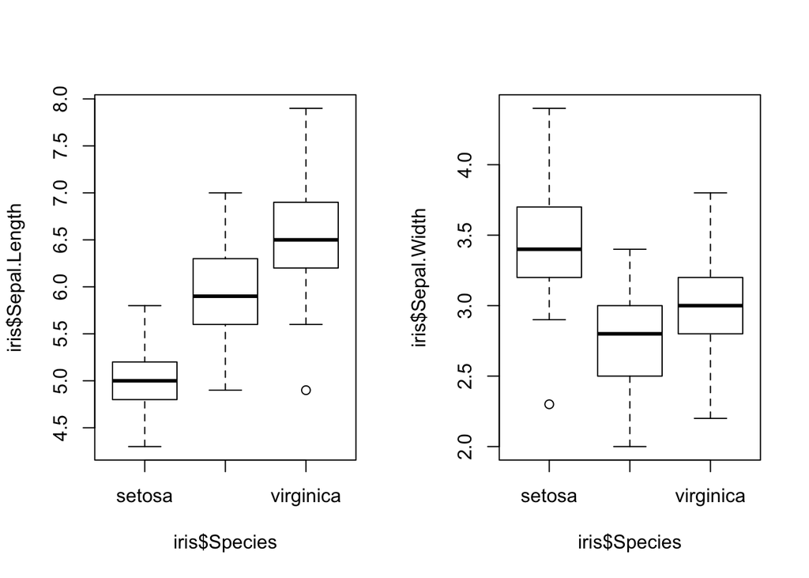

```r
par(mfrow = c(1,2))
boxplot(iris$Sepal.Length ~ iris$Species)
boxplot(iris$Sepal.Width ~ iris$Species)
```

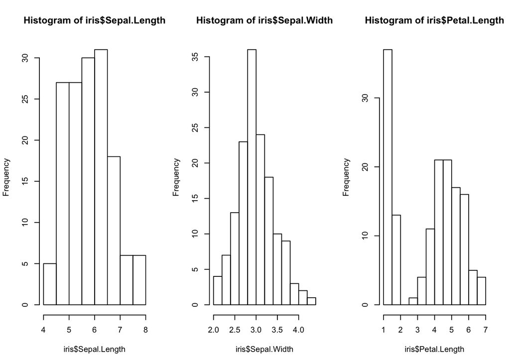

```r
# some histograms
par(mfrow = c(1,3))
hist(iris$Sepal.Length)
hist(iris$Sepal.Width)
hist(iris$Petal.Length)

library(Hmisc)
```

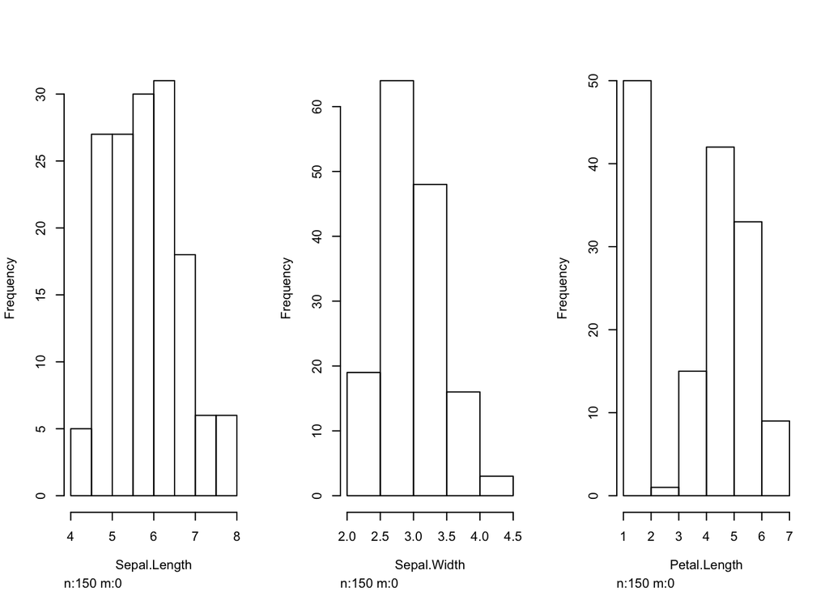

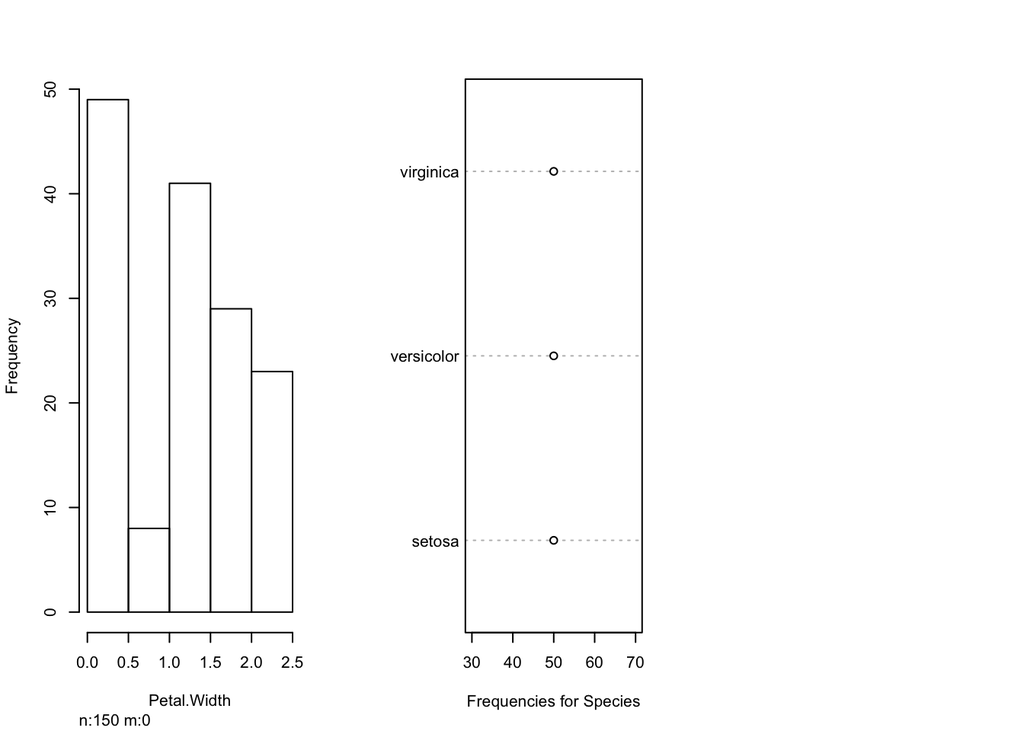

```r
hist.data.frame(iris)
```

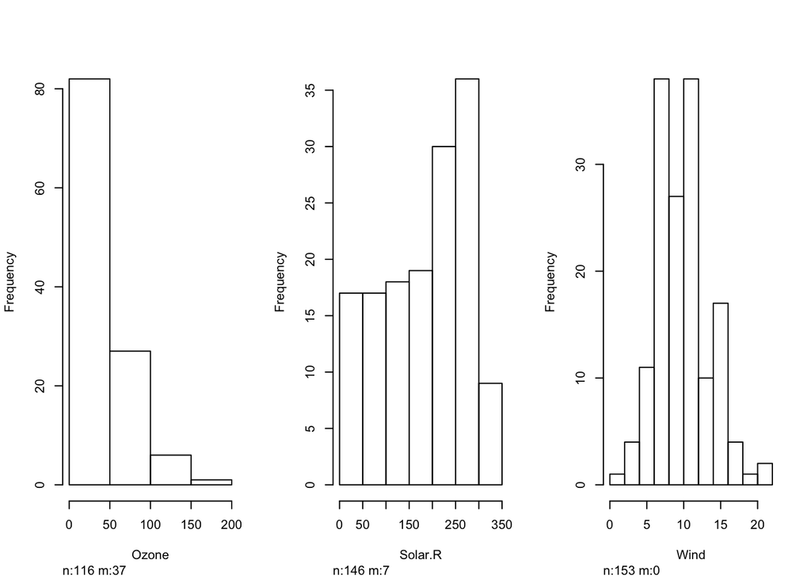

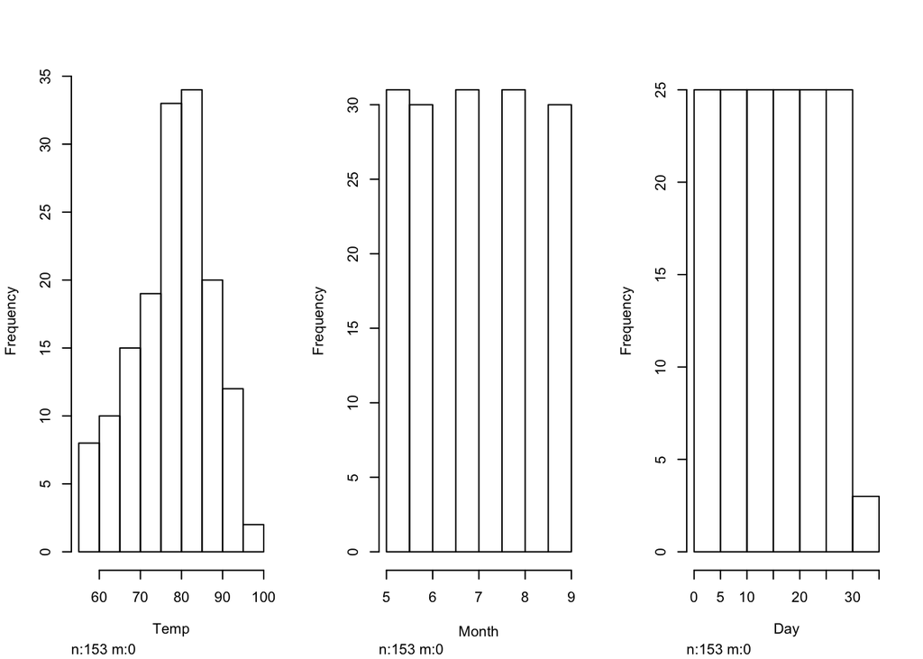

```r
hist.data.frame(airquality)
```

### Boxcox Transformations

Boxcox transformations are used to transform a predictor variable with non-normal distribution into predictor with normal distribution.

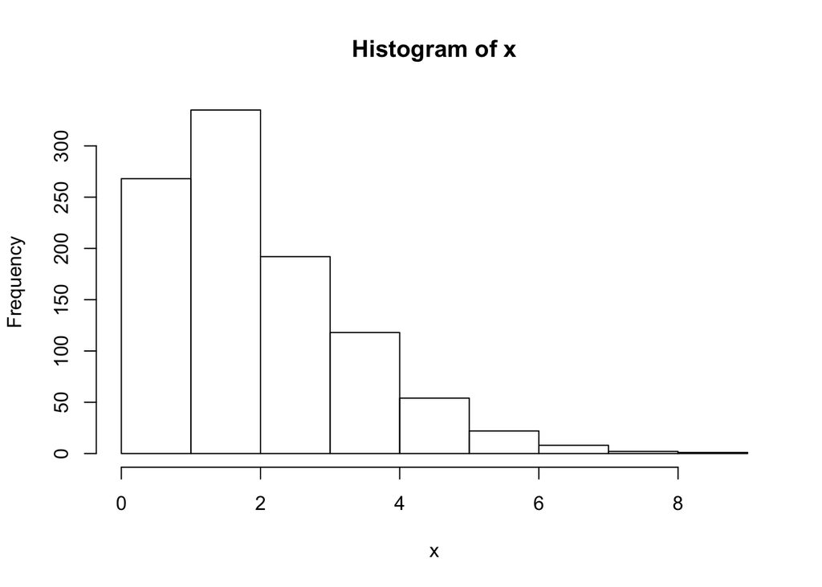

```r
set.seed(20)
x <- rgamma(1000, 2)
hist(x)
```

```r
library(e1071)
skewness(x)
```

```
## [1] 1.155639
```

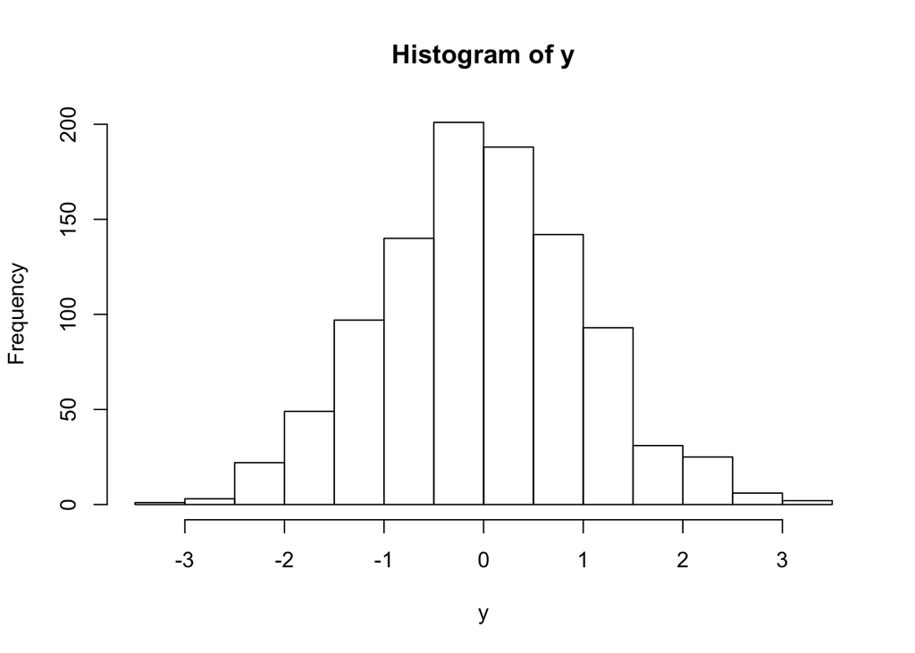

```r
y <- rnorm(1000)
hist(y)
```

```r
skewness(y)
```

```
## [1] 0.05625155
```

```r
library(caret)
```

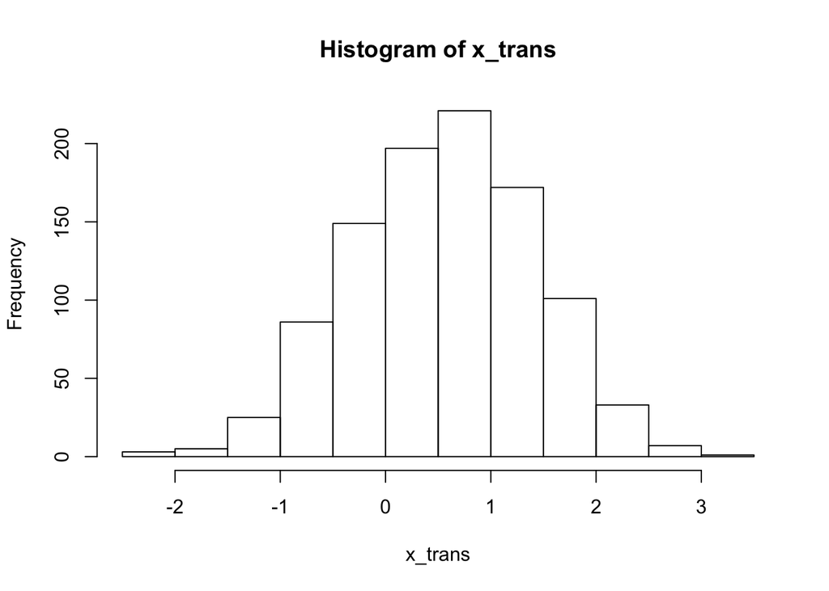

```r
bct <- BoxCoxTrans(x)
x_trans <- predict(bct, x)
hist(x_trans)
```

```r
skewness(x_trans)
```

```
## [1] -0.1014337
```

```r
z <- c(x, 0)
bct2 <- BoxCoxTrans(z)
z <- z + 10^-4
bct2 <- BoxCoxTrans(z)
```

### Principal Component Analysis

It is commonly used for dimensionality reduction by projecting each data point onto only the first few principal components to obtain lower-dimensional data while preserving as much of the data’s variation as possible.

Principal components are directions that have maximum variance when data is projected onto them and at the same time are uncorrelated with each other.

Principal components are linear combinations of original predictors.

```r
# Example 1

set.seed(100)
x <- rnorm(1000)
y <- rnorm(1000)
z <- rnorm(1000)

m <- matrix(data = c(x, y, z), nrow = 1000, ncol = 3)

m_pca <- prcomp(m)
str(m_pca)
```

```
## List of 5
##  $ sdev    : num [1:3] 1.08 1.02 0.96
##  $ rotation: num [1:3, 1:3] 0.398 0.384 -0.833 -0.917 0.204 ...
##   ..- attr(*, "dimnames")=List of 2
##   .. ..$ : NULL
##   .. ..$ : chr [1:3] "PC1" "PC2" "PC3"
##  $ center  : num [1:3] 0.01681 0.00415 -0.01491
##  $ scale   : logi FALSE
##  $ x       : num [1:1000, 1:3] -0.923 0.677 1.617 1.268 0.663 ...
##   ..- attr(*, "dimnames")=List of 2
##   .. ..$ : NULL
##   .. ..$ : chr [1:3] "PC1" "PC2" "PC3"
##  - attr(*, "class")= chr "prcomp"
```

```r
m_pca_var <- m_pca$sdev^2
m_pca_var * 100/sum(m_pca_var)
```

```
## [1] 37.19385 33.34731 29.45884
```

```r
m_pca_var
```

```
## [1] 1.1636060 1.0432675 0.9216168
```

```r
m_pca$rotation
```

```
##             PC1        PC2        PC3
## [1,]  0.3975310 -0.9168128 0.03772701
## [2,]  0.3842259  0.2036564 0.90049681
## [3,] -0.8332704 -0.3434797 0.43322300
```

```r
# m_pca$x # Use this to print all rows
m_pca$x[1:20,] # Use this to print first 20 rows
```

```
##               PC1          PC2         PC3
##  [1,] -0.92255632  0.230094334  1.55593363
##  [2,]  0.67681329  0.208289765  0.97104282
##  [3,]  1.61729564  0.796517339 -0.22238709
##  [4,]  1.26803842 -0.368936885  0.73287199
##  [5,]  0.66294182  0.216296900  0.92586274
##  [6,]  1.51265550  0.331586404  0.11928384
##  [7,] -0.39804192  0.489287843  0.21797642
##  [8,]  1.13338578 -0.238732641  0.75008575
##  [9,]  0.40485984  1.057495589 -0.88751580
## [10,] -0.43139627  0.212063844 -0.28496776
## [11,] -1.46981059 -0.732636420 -0.37941417
## [12,]  0.36507151  0.006083782 -1.59249778
## [13,]  1.26914070  0.782704140 -0.14230131
## [14,]  0.93153037 -0.401242501 -0.40133218
## [15,]  0.04234523 -0.146562409 -1.18295701
## [16,]  0.22601833  0.162264731  0.33915479
## [17,]  0.74031926  0.734376144 -0.70701898
## [18,] -0.38481085 -0.725154437 -0.47195619
## [19,] -0.91199935  0.615836932 -0.09181926
## [20,]  1.44672574 -1.894243224 -0.48488072
```

```r
# Example 2

t <- (x + y + z)/3
m1 <- matrix(data = c(x, y, z, t), nrow = 1000, ncol = 4)

m1_pca <- prcomp(m1)
m1_pca_var <- m1_pca$sdev^2
m1_pca_var * 100/sum(m1_pca_var)
```

```
## [1] 3.781024e+01 3.370797e+01 2.848179e+01 7.839055e-30
```

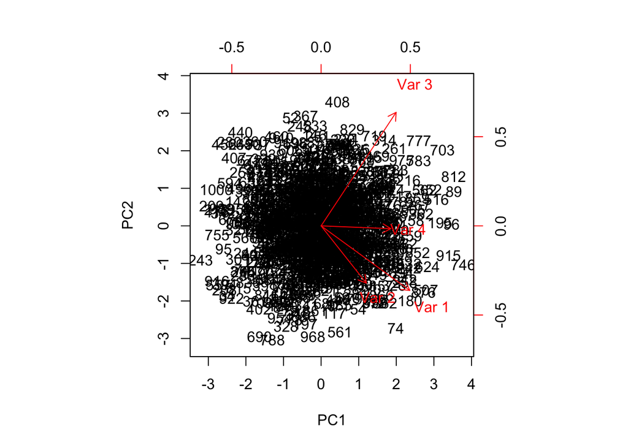

```r
biplot(m1_pca, scale = 0)
```

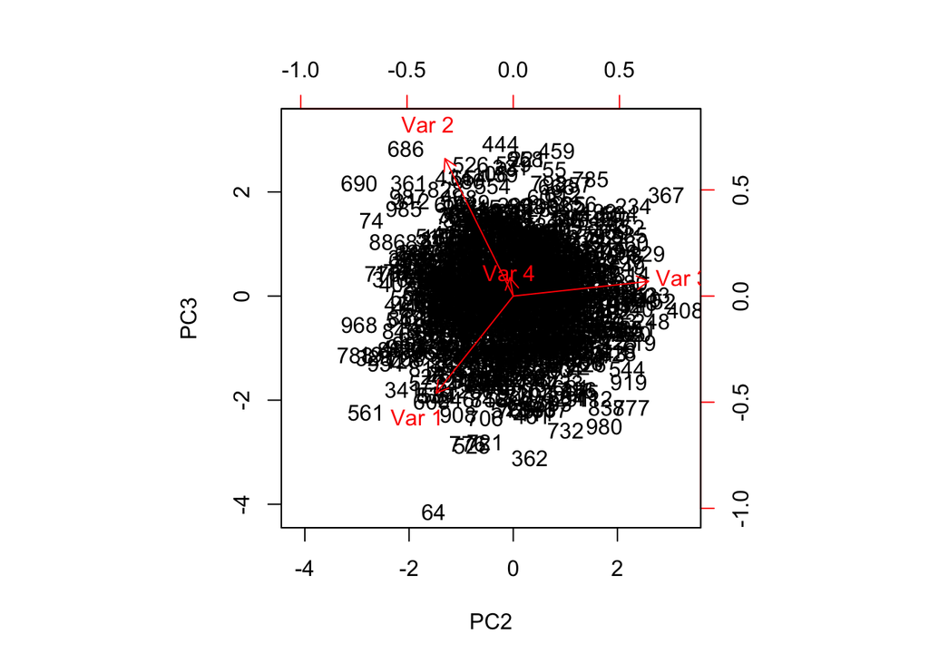

```r
biplot(m1_pca, choices = 2:3, scale = 0)
```

```r
# Example 3

t <- exp(x)* y + z
m2 <- matrix(data = c(x, y, z, t), nrow = 1000, ncol = 4)

m2_pca <- prcomp(m2, scale. = TRUE)
m2_pca_var <- m2_pca$sdev^2
cumsum(m2_pca_var) * 100/sum(m2_pca_var) # top 3 components capture more 90% of variance
```

```
## [1]  39.39414  66.71247  91.15092 100.00000
```

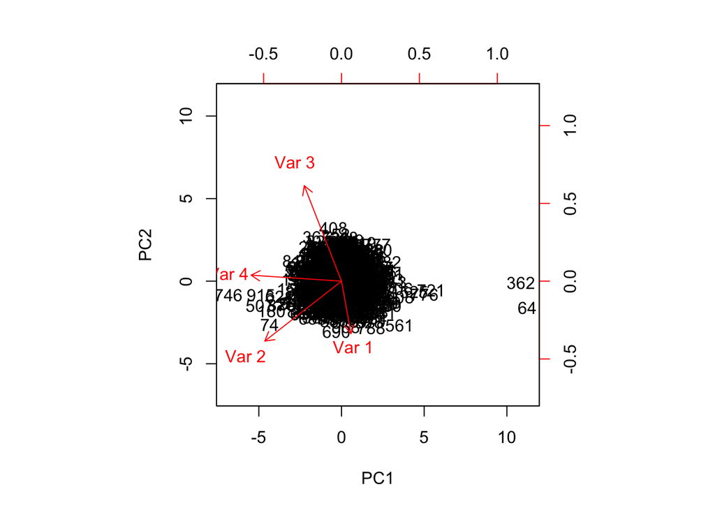

```r
biplot(m2_pca, scale = 0)
```

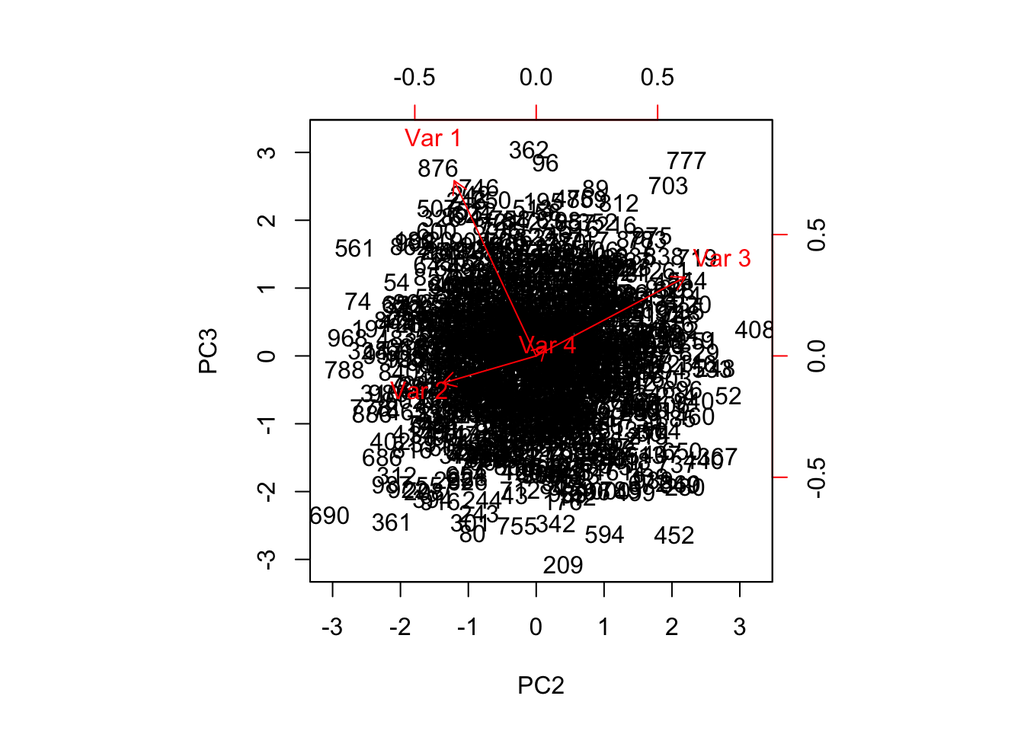

```r
biplot(m2_pca, choices = 2:3, scale = 0)
```

```r
# Example 4

x <- rnorm(1000)
y <- rnorm(1000)
z <- rnorm(1000)
t <- rnorm(1000, mean = 0, sd = 4)

m3 <- matrix(data = c(x, y, z, t), nrow = 1000, ncol = 4)

m3_pca <- prcomp(m3)
m3_pca_var <- m3_pca$sdev^2
m3_pca_var * 100/sum(m3_pca_var)
```

```
## [1] 84.790628  5.383124  5.137736  4.688513
```